# Essentials of Data Analytics - Jcomp

### Checking Assumptions

#### a.Multicollinearity

```r
vif(model1)
```

```
## Humidity3pm     Temp3pm Pressure3pm
##    1.212549    1.357598    1.138781
```

#### Since, all the values are less than 5, we can conclude that there is no multicollinearity.

```r
vif(model2)
```

```
## Humidity9am     Temp9am Pressure9am
##    1.245679    1.397464    1.180271
```

#### Since, all the values are less than 5, we can conclude that there is no multicollinearity in model2 as well.

```r
vif(model3)
```

```
##       MinTemp       MaxTemp   Evaporation      Sunshine WindGustSpeed
##     10.684660     17.985812      1.317414      1.678540      2.308052
##  WindSpeed9am  WindSpeed3pm   Humidity9am   Humidity3pm   Pressure9am
##      1.897066      2.015996      2.572086      3.365428     16.359538
##   Pressure3pm      Cloud9am      Cloud3pm       Temp9am       Temp3pm
##     16.324931      1.523306      1.578307     19.637307     19.006800
```

#### Since, some of the values are not than 5, we can conclude that there is multicollinearity in model3.

#### b. Finding Outliers

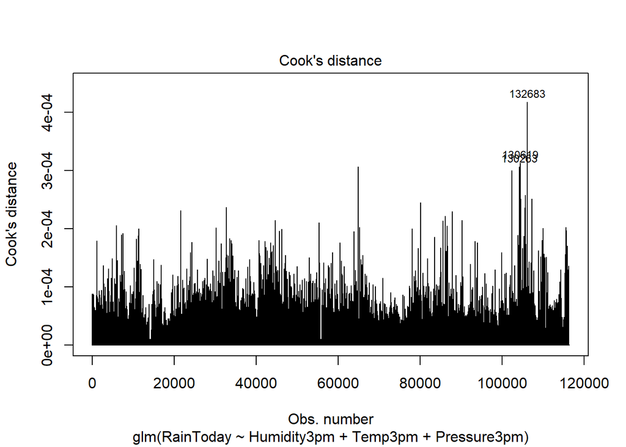

```r
plot(model1,4)
```

#### Plotting the standardized residuals

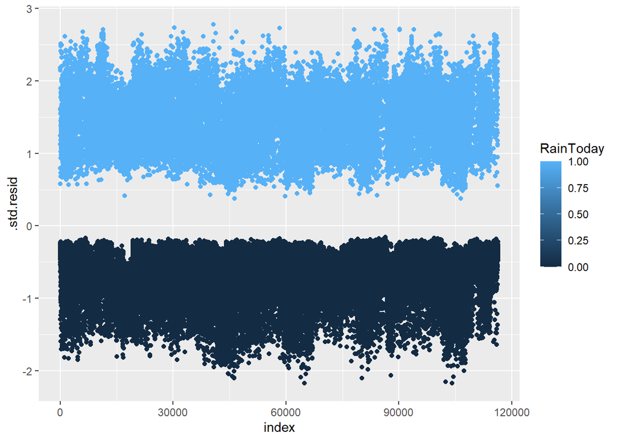

```r
model_data <- augment(model1) %>%
              mutate(index=1:n())

ggplot(model_data,aes(index,.std.resid))+geom_point(aes(col=RainToday))
```

## 2.Decision Tree

### Model Building

```r
model1<-rpart(RainToday~.-Rainfall-RainTomorrow,data=train_data, method="class",control =rpart.control(cp=0,maxdepth=5,minsplit=3 ))
```

#### Here we are taking all the rows, except Rainfall and RainTommorow.

### Visualisation1 of the decision tree

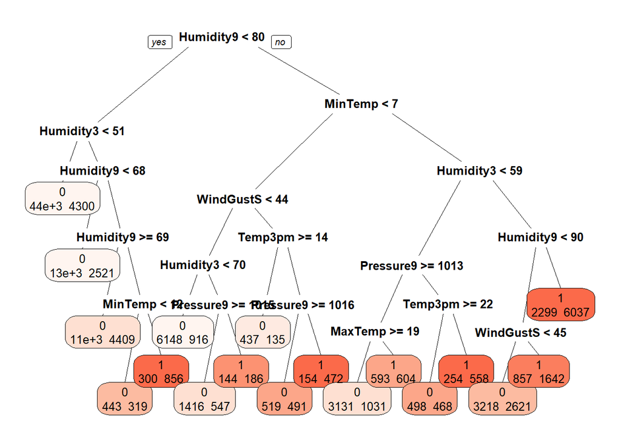

```r
prp(model1, faclen = 0,box.palette = "Reds", cex = 0.8, extra = 1)
```

### Accuracy before pruining

```r
pred <- model1%>%predict(test_data,type="class")
mean(pred==test_data$RainToday)
```

```
## [1] 0.8034167
```

### Pruning the tree

#### Finding the best cp using graph

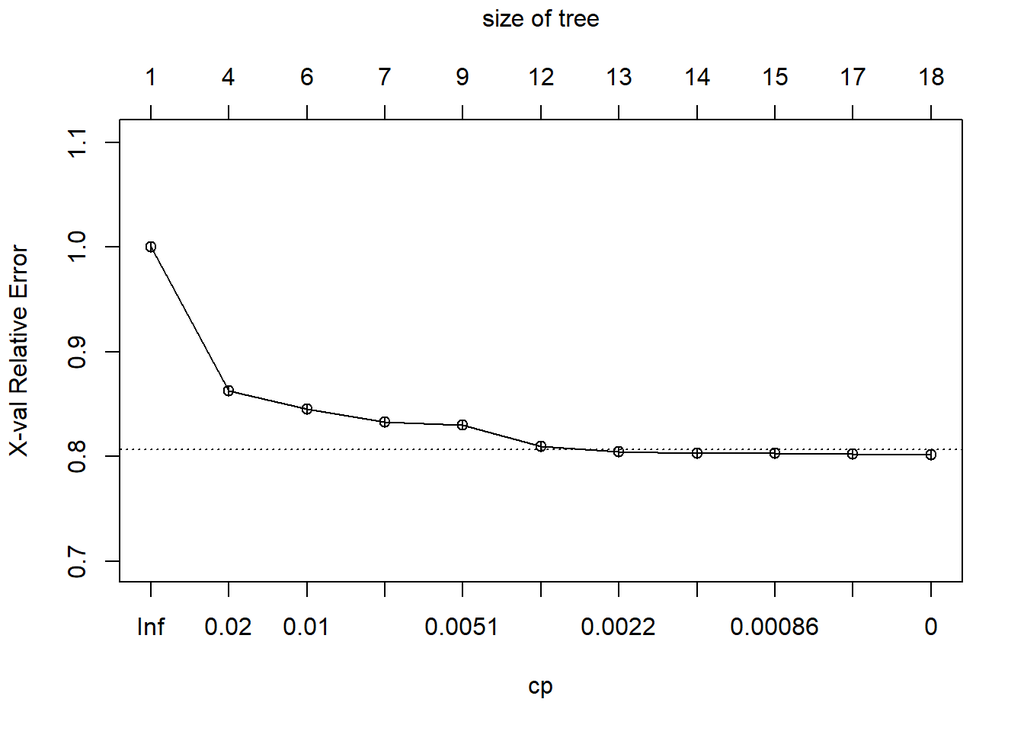

```r
plotcp(model1)
```

#### From the above plot, we can observe, the cp-val is ‘0’ for least error.